# Final Assignment Analytical Design - The last update

## Step One: Exploratory Data Analysis

[figure not shown]

### Some Clarifications:

```
    - In this part, I dedicated the initial efforts to organise and clean the raw dataset. Using multiple sources primarily Module lectures -- Stackoverflow.com -- Google.com -- Medium.com.
    - Before starting with the data wrangling, I have dedicated the time to understand the raw dataset itself. Thanks to the previous image I am able to distinguish the flower parts. From that point it was easy the cleaning part. The visualisation section, it was challenging as I had to choose the suitable colors, other plots to reflect my interpretation to the model.
    - I wouldn't grasp the essential angle without the help of the textbook and the module videos.
    - Finally, I like the effort I spent in this project, as it enables me to polish my skill in data fluency and storytelling.
```

## Data Wrangling

```python
# Import the requred libraries -- pandas & numpy for the exploratory data analysis "EDA" -- seaborn & matplotlib for
#visulaisations

import pandas as pd
import numpy as np
import seaborn as sns
import matplotlib.pyplot as plt
```

### *1 Retrieving the raw dataset*

```python
# First recall the raw dataset using the link provided in the assignment page

df = pd.read_csv('https://archive.ics.uci.edu/ml/machine-learning-databases/iris/iris.data',  header=None, skiprows=[0])
df

#I have used the next reference as I didn't want the first row to become the header.
# https://stackoverflow.com/questions/54304551/python-csv-file-reading-turning-the-first-row-into-column-headers-nextreader
```

|  | 0 | 1 | 2 | 3 | 4 |
| --- | --- | --- | --- | --- | --- |
| 0 | 4.9 | 3.0 | 1.4 | 0.2 | Iris-setosa |
| 1 | 4.7 | 3.2 | 1.3 | 0.2 | Iris-setosa |
| 2 | 4.6 | 3.1 | 1.5 | 0.2 | Iris-setosa |
| 3 | 5.0 | 3.6 | 1.4 | 0.2 | Iris-setosa |
| 4 | 5.4 | 3.9 | 1.7 | 0.4 | Iris-setosa |
| ... | ... | ... | ... | ... | ... |
| 144 | 6.7 | 3.0 | 5.2 | 2.3 | Iris-virginica |
| 145 | 6.3 | 2.5 | 5.0 | 1.9 | Iris-virginica |
| 146 | 6.5 | 3.0 | 5.2 | 2.0 | Iris-virginica |
| 147 | 6.2 | 3.4 | 5.4 | 2.3 | Iris-virginica |
| 148 | 5.9 | 3.0 | 5.1 | 1.8 | Iris-virginica |

149 rows × 5 columns

### *Rename the main columns of the dataset*

```python
df.columns = ['sepal_length', 'sepal_width', 'petal_length', 'petal_width', 'flower name']
```

### *Checking the characteristics of the raw dataset*

```python
df.info()
```

```
<class 'pandas.core.frame.DataFrame'>
RangeIndex: 149 entries, 0 to 148
Data columns (total 5 columns):
 #   Column        Non-Null Count  Dtype
---  ------        --------------  -----
 0   sepal_length  149 non-null    float64
 1   sepal_width   149 non-null    float64
 2   petal_length  149 non-null    float64
 3   petal_width   149 non-null    float64
 4   flower name   149 non-null    object
dtypes: float64(4), object(1)
memory usage: 5.9+ KB
```

### *The "flower name" column is basically contains 3 parts (iris word) & (-) & (the flower actual type)*

```
The (flower actual type) part is what we want so I refrain the column a bit.
```

```python
# Split the (flower name) column

df['flower name'] = df['flower name'].str.replace('-', ' ')
```

```python
# Checking the outputs

df['flower name']
```

```
0         Iris setosa
1         Iris setosa
2         Iris setosa
3         Iris setosa
4         Iris setosa
            ...
144    Iris virginica
145    Iris virginica
146    Iris virginica
147    Iris virginica
148    Iris virginica
Name: flower name, Length: 149, dtype: object
```

```python
# Rename the flower name into flower_name after removing the iris and special character

df[['Iris_word','flower_name']] = df['flower name'].str.split(expand=True)
```

```python
# Drop the unnecessary columns from the main dataset

df = df.drop(['flower name', 'Iris_word'], axis=1)
```

```python
# Let's captialize the first letter of every word in the (flower_name) column

df['flower_name'] = df['flower_name'].str.capitalize()
```

## *1.1 Show the first 10 rows*

```python
# Make sure that the new changes are done correctly

df.head(10)
```

|  | sepal_length | sepal_width | petal_length | petal_width | flower_name |
| --- | --- | --- | --- | --- | --- |
| 0 | 4.9 | 3.0 | 1.4 | 0.2 | Setosa |
| 1 | 4.7 | 3.2 | 1.3 | 0.2 | Setosa |
| 2 | 4.6 | 3.1 | 1.5 | 0.2 | Setosa |
| 3 | 5.0 | 3.6 | 1.4 | 0.2 | Setosa |
| 4 | 5.4 | 3.9 | 1.7 | 0.4 | Setosa |
| 5 | 4.6 | 3.4 | 1.4 | 0.3 | Setosa |
| 6 | 5.0 | 3.4 | 1.5 | 0.2 | Setosa |
| 7 | 4.4 | 2.9 | 1.4 | 0.2 | Setosa |
| 8 | 4.9 | 3.1 | 1.5 | 0.1 | Setosa |
| 9 | 5.4 | 3.7 | 1.5 | 0.2 | Setosa |

```python
# Visualize the first 10 rows without the flower name

df0 = df.drop(['flower_name'], axis=1)
```

```python
df0.head(10)
```

|  | sepal_length | sepal_width | petal_length | petal_width |
| --- | --- | --- | --- | --- |
| 0 | 4.9 | 3.0 | 1.4 | 0.2 |
| 1 | 4.7 | 3.2 | 1.3 | 0.2 |
| 2 | 4.6 | 3.1 | 1.5 | 0.2 |
| 3 | 5.0 | 3.6 | 1.4 | 0.2 |
| 4 | 5.4 | 3.9 | 1.7 | 0.4 |
| 5 | 4.6 | 3.4 | 1.4 | 0.3 |
| 6 | 5.0 | 3.4 | 1.5 | 0.2 |
| 7 | 4.4 | 2.9 | 1.4 | 0.2 |
| 8 | 4.9 | 3.1 | 1.5 | 0.1 |
| 9 | 5.4 | 3.7 | 1.5 | 0.2 |

### *1.1.1 Checking the NaN values -- Zeros -- NA values in the new edited dataset*

```python
# Count the zero vlaues in the dataframe "df"

(df == 0).astype(int).sum(axis=0)
```

```
sepal_length    0
sepal_width     0
petal_length    0
petal_width     0
flower_name     0
dtype: int64
```

```python
# Count the NaN values

df.isna().sum()
```

```
sepal_length    0
sepal_width     0
petal_length    0
petal_width     0
flower_name     0
dtype: int64
```

```python
# Check the size of the dataset

df.groupby('flower_name').size()
```

```
flower_name
Setosa        49
Versicolor    50
Virginica     50
dtype: int64
```

## Observation:

```
 it's clearly that there is no Null values nor zeros in this dataset.
```

### *2 Checking the statistical features using describe() function*

```python
# First I have started with the whole data

round(df.describe().T,2)
```

|  | count | mean | std | min | 25% | 50% | 75% | max |
| --- | --- | --- | --- | --- | --- | --- | --- | --- |
| sepal_length | 149.0 | 5.85 | 0.83 | 4.3 | 5.1 | 5.8 | 6.4 | 7.9 |
| sepal_width | 149.0 | 3.05 | 0.43 | 2.0 | 2.8 | 3.0 | 3.3 | 4.4 |
| petal_length | 149.0 | 3.77 | 1.76 | 1.0 | 1.6 | 4.4 | 5.1 | 6.9 |
| petal_width | 149.0 | 1.21 | 0.76 | 0.1 | 0.3 | 1.3 | 1.8 | 2.5 |

### *2.1 Select the rows that are associated to each flower type*

```python
# Starting with Setosa

Setosa = df[df['flower_name'] == 'Setosa']

# I have used the next reference to generate the function correctly.
# https://stackoverflow.com/questions/33742588/pandas-split-dataframe-by-column-value
```

```python
# Compute the main statistical features for Setosa type, I have used T function to reverse the rows into columns
#to make it more elegant

round(Setosa.describe().T, 2)
```

|  | count | mean | std | min | 25% | 50% | 75% | max |
| --- | --- | --- | --- | --- | --- | --- | --- | --- |
| sepal_length | 49.0 | 5.00 | 0.36 | 4.3 | 4.8 | 5.0 | 5.2 | 5.8 |
| sepal_width | 49.0 | 3.42 | 0.38 | 2.3 | 3.1 | 3.4 | 3.7 | 4.4 |
| petal_length | 49.0 | 1.47 | 0.18 | 1.0 | 1.4 | 1.5 | 1.6 | 1.9 |
| petal_width | 49.0 | 0.24 | 0.11 | 0.1 | 0.2 | 0.2 | 0.3 | 0.6 |

```python
# Then Versicolor

Versicolor = df[df['flower_name'] == 'Versicolor']
```

```python
round(Versicolor.describe().T, 2)
```

|  | count | mean | std | min | 25% | 50% | 75% | max |
| --- | --- | --- | --- | --- | --- | --- | --- | --- |
| sepal_length | 50.0 | 5.94 | 0.52 | 4.9 | 5.60 | 5.90 | 6.3 | 7.0 |
| sepal_width | 50.0 | 2.77 | 0.31 | 2.0 | 2.52 | 2.80 | 3.0 | 3.4 |
| petal_length | 50.0 | 4.26 | 0.47 | 3.0 | 4.00 | 4.35 | 4.6 | 5.1 |
| petal_width | 50.0 | 1.33 | 0.20 | 1.0 | 1.20 | 1.30 | 1.5 | 1.8 |

```python
# Finally Virginica

Virginica = df[df['flower_name'] == 'Virginica']
```

```python
round(Virginica.describe().T, 2)
```

|  | count | mean | std | min | 25% | 50% | 75% | max |
| --- | --- | --- | --- | --- | --- | --- | --- | --- |
| sepal_length | 50.0 | 6.59 | 0.64 | 4.9 | 6.22 | 6.50 | 6.90 | 7.9 |
| sepal_width | 50.0 | 2.97 | 0.32 | 2.2 | 2.80 | 3.00 | 3.18 | 3.8 |
| petal_length | 50.0 | 5.55 | 0.55 | 4.5 | 5.10 | 5.55 | 5.88 | 6.9 |
| petal_width | 50.0 | 2.03 | 0.27 | 1.4 | 1.80 | 2.00 | 2.30 | 2.5 |

### *Generate the three species in one group as required*

```python
round(df.groupby('flower_name').describe().T,2)
```

|  | flower_name | Setosa | Versicolor | Virginica |
| --- | --- | --- | --- | --- |
| sepal_length | count | 49.00 | 50.00 | 50.00 |
|  | mean | 5.00 | 5.94 | 6.59 |
|  | std | 0.36 | 0.52 | 0.64 |
|  | min | 4.30 | 4.90 | 4.90 |
|  | 25% | 4.80 | 5.60 | 6.22 |
|  | 50% | 5.00 | 5.90 | 6.50 |
|  | 75% | 5.20 | 6.30 | 6.90 |
|  | max | 5.80 | 7.00 | 7.90 |
| sepal_width | count | 49.00 | 50.00 | 50.00 |
|  | mean | 3.42 | 2.77 | 2.97 |
|  | std | 0.38 | 0.31 | 0.32 |
|  | min | 2.30 | 2.00 | 2.20 |
|  | 25% | 3.10 | 2.52 | 2.80 |
|  | 50% | 3.40 | 2.80 | 3.00 |
|  | 75% | 3.70 | 3.00 | 3.18 |
|  | max | 4.40 | 3.40 | 3.80 |
| petal_length | count | 49.00 | 50.00 | 50.00 |
|  | mean | 1.47 | 4.26 | 5.55 |
|  | std | 0.18 | 0.47 | 0.55 |
|  | min | 1.00 | 3.00 | 4.50 |
|  | 25% | 1.40 | 4.00 | 5.10 |
|  | 50% | 1.50 | 4.35 | 5.55 |
|  | 75% | 1.60 | 4.60 | 5.88 |
|  | max | 1.90 | 5.10 | 6.90 |
| petal_width | count | 49.00 | 50.00 | 50.00 |
|  | mean | 0.24 | 1.33 | 2.03 |
|  | std | 0.11 | 0.20 | 0.27 |
|  | min | 0.10 | 1.00 | 1.40 |
|  | 25% | 0.20 | 1.20 | 1.80 |
|  | 50% | 0.20 | 1.30 | 2.00 |
|  | 75% | 0.30 | 1.50 | 2.30 |
|  | max | 0.60 | 1.80 | 2.50 |

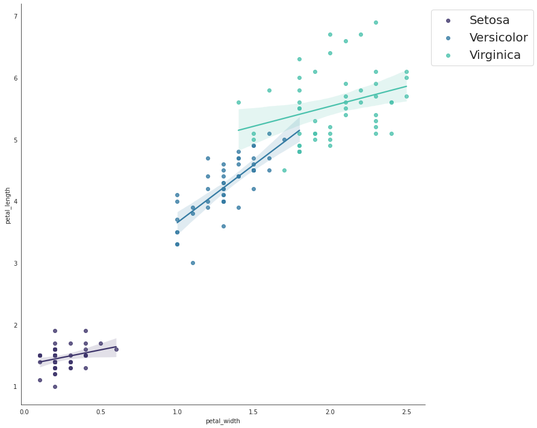

```python
#scatter chart

sns.set_style("white")

plt.figure(figsize=(10,10))

sns.lmplot(data=df, x="petal_width", y="petal_length", hue="flower_name", palette="mako", height=10, legend=False)
plt.legend(bbox_to_anchor=(1, 1), loc='best', fontsize=20)
```

### Exploration Interpretation:

This exploration represents the scatter chart associated with the regression line. The regression line plays a vital role in identifying the outliers and the general estimate of the model residuals "errors". Outliers are the observations that have extreme values. Ususally outliers might come with an idea of eliminating them, but that's not true, anomalies need to be detected and studied as they might reflect real type of observations. Usually we start with the hypothesis testing in favor of anomaly detection.

When it comes to the residual rates, it's another factor that reflects the accuracy of our model, especially while prediction.

For this chart, the best values that are spread around the regression line just like the flower Versicolor, unlike the Virignica flower that most of the values are quite abroad from the regression line which gives the residual rate to increase.

The basic equation for regression is:

(Yi) > Dependent value (Xi) > Independent value Intercept > Beta, and the residual.

Yi = Intercept + Beta * Xi + E "E stands for the Error factor".

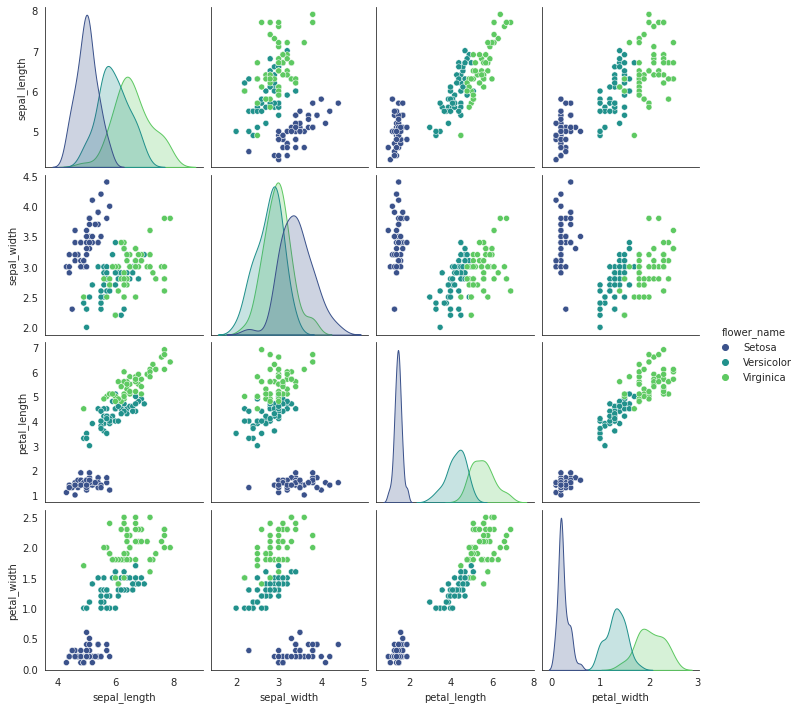

```python
# pairplot with hue flower_name column
sns.pairplot(df, hue ='flower_name', palette = 'viridis')

plt.xticks(fontsize = 20)
plt.yticks(fontsize = 20)

# to show
plt.show()

# https://seaborn.pydata.org/generated/seaborn.pairplot.html
```

### Exploration Interpretation:

This exploration is one of the best visualisation individual can use while building a model. It gives everything in one place, so let's get started:

```
- The pairwise is a combination between a single variable exploration "The histograms" where they represent the variable intersection with itself and shows the distribution.

- The rest of the plots are scatter charts where they highlight the interaction between the two variables, promising analysis can be made such as finding the corelation coefficient if one of the scatter plots draw close attention.
```

*That's in general, but what can be gained from the Iris dataset pairwise plot?*

[output not shown]

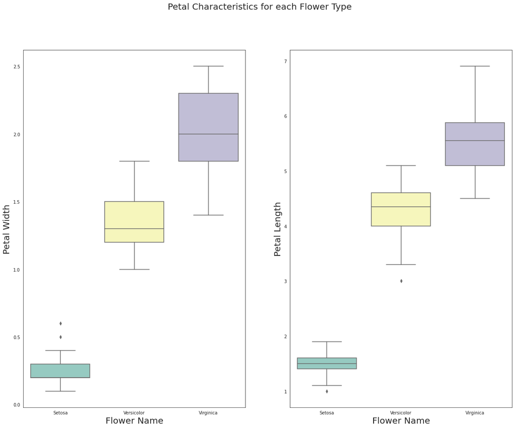

```python
fig, axes = plt.subplots(1, 2, figsize=(20,15))

sns.boxplot(x='flower_name', y="petal_width", data=df, palette="Set3", orient='v', ax=axes[0])
sns.boxplot(x='flower_name', y="petal_length", data=df, palette="Set3", orient='v', ax=axes[1])
fig.suptitle('Petal Characteristics for each Flower Type', fontsize = 20)
#fig.supxlabel('Flower Name', fontsize = 20)

axes[0].set_ylabel("Petal Width",fontsize = 20)
axes[0].set_xlabel("Flower Name",fontsize = 20)

axes[1].set_ylabel("Petal Length",fontsize = 20)
axes[1].set_xlabel("Flower Name",fontsize = 20)


plt.show()

# https://dev.to/thalesbruno/subplotting-with-matplotlib-and-seaborn-5ei8

#https://stackabuse.com/seaborn-box-plot-tutorial-and-examples/
```

### Exploration Interpretation:

From the box plot, we can identify the outliers easily by observing the whisker as an example looking at the relation between the petal width and flower type, we can see that the Setosa type has two points above the whisker. For advance analysis, and with the limited observations we have regarding this flower type. We need to check the outliers and observe the effect on the analysis itself.

However generally, we conclude that the petal length median for the Virginca flower is between 5 and 6 cm. On the other hand the petal width median in between 1.5 & 2 cm.

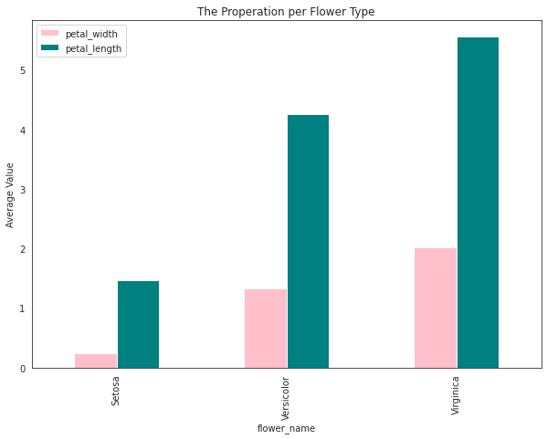

```python
# Categorical exploration "Bar plot"  ('pink', 'cyan')


df.groupby('flower_name')[["petal_width", "petal_length"]].mean().plot.bar(figsize=(10,7),  color = ('pink', 'teal'))
plt.ylabel('Average Value')
plt.title('The Properation per Flower Type')
```

### Exploration Interpretation:

In this bar plot, I want to check the average number for each specie with the respect to the petal width and length. As you can see here although the three species have the same size each one of them contains from 49 observations to 50 observations. Still the variance is massive between them. That impacts if the observations are normally distributed or not. But that's another story. I just wanted to see the shape and aggregation of the flower types.

### 4. The three clusters

```python
# Rename the (flower name) column

df['flower_name'] = df['flower_name'].replace(['Setosa', 'Versicolor', 'Virginica'],[0, 1, 2], inplace=False)
```

```python
# Double check my output

df
```

|  | sepal_length | sepal_width | petal_length | petal_width | flower_name |
| --- | --- | --- | --- | --- | --- |
| 0 | 4.9 | 3.0 | 1.4 | 0.2 | 0 |
| 1 | 4.7 | 3.2 | 1.3 | 0.2 | 0 |
| 2 | 4.6 | 3.1 | 1.5 | 0.2 | 0 |
| 3 | 5.0 | 3.6 | 1.4 | 0.2 | 0 |
| 4 | 5.4 | 3.9 | 1.7 | 0.4 | 0 |
| ... | ... | ... | ... | ... | ... |
| 144 | 6.7 | 3.0 | 5.2 | 2.3 | 2 |
| 145 | 6.3 | 2.5 | 5.0 | 1.9 | 2 |
| 146 | 6.5 | 3.0 | 5.2 | 2.0 | 2 |
| 147 | 6.2 | 3.4 | 5.4 | 2.3 | 2 |
| 148 | 5.9 | 3.0 | 5.1 | 1.8 | 2 |

149 rows × 5 columns

```python
# Create a loop to execute the code on the whole dataset.

centers = {}

for i in range(3):
    output_array = []
    output_array.append(df.loc[df['flower_name'] == i]["petal_width"].mean())
    output_array.append(df.loc[df['flower_name'] == i]["petal_length"].mean())

    centers[i] = output_array
```

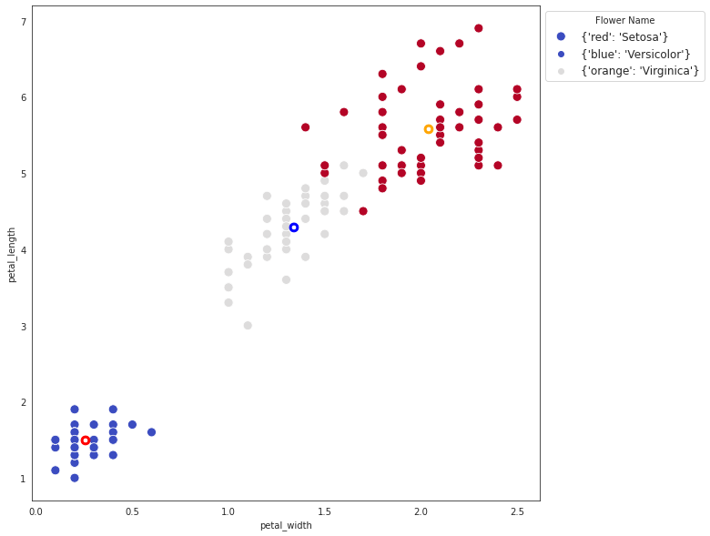

```python
# Plotting the 3 clusters with the centroids

sns.set_style("white")
plt.figure(figsize=(10,10))


exploration = sns.scatterplot(data=df, x="petal_width", y="petal_length", hue = "flower_name", palette = "coolwarm", s=100)

colors = {0 : 'red', 1: 'blue', 2: 'orange'}
for i in range(3):
    plt.scatter(centers[i][0], centers[i][1], color  = colors[i], s=220, marker="$\circ$")

plt.legend(bbox_to_anchor=(1, 1), title='Flower Name', loc='upper left',
           labels=[{'red' : 'Setosa'},{'blue' : 'Versicolor'} , {'orange' :'Virginica'}], fontsize=12)


plt.show(exploration)
```

### Exploration Interpretation:

In the next section, it's about the last point of step one which is the plotting the 3 clusters.

```python
# Recall the data that above the 6 data records

New_data = df.iloc[6:150, 0:2]
New_data
```

|  | sepal_length | sepal_width |
| --- | --- | --- |
| 6 | 5.0 | 3.4 |
| 7 | 4.4 | 2.9 |
| 8 | 4.9 | 3.1 |
| 9 | 5.4 | 3.7 |
| 10 | 4.8 | 3.4 |
| ... | ... | ... |
| 144 | 6.7 | 3.0 |
| 145 | 6.3 | 2.5 |
| 146 | 6.5 | 3.0 |
| 147 | 6.2 | 3.4 |
| 148 | 5.9 | 3.0 |

143 rows × 2 columns

```python
# Re-order the data so the sepal width is on the X axis & sepal length is on the Y axis

New_data = New_data[["sepal_width", "sepal_length"]]
New_data
```

|  | sepal_width | sepal_length |
| --- | --- | --- |
| 6 | 3.4 | 5.0 |
| 7 | 2.9 | 4.4 |
| 8 | 3.1 | 4.9 |
| 9 | 3.7 | 5.4 |
| 10 | 3.4 | 4.8 |
| ... | ... | ... |
| 144 | 3.0 | 6.7 |
| 145 | 2.5 | 6.3 |
| 146 | 3.0 | 6.5 |
| 147 | 3.4 | 6.2 |
| 148 | 3.0 | 5.9 |

143 rows × 2 columns

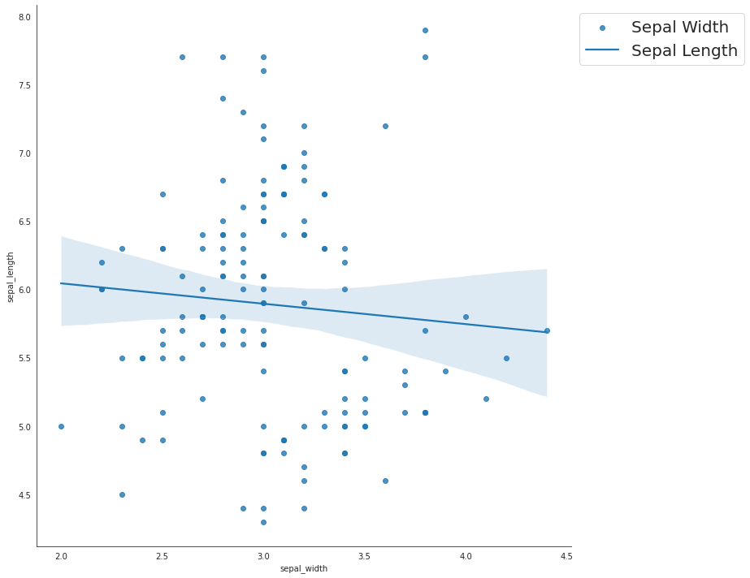

```python
#scatter chart

sns.set_style("white")

plt.figure(figsize=(10,10))

sns.lmplot(data=New_data, x="sepal_width", y="sepal_length", palette="mako", height=10, legend=False)
plt.legend(bbox_to_anchor=(1, 1), loc='best', labels = ["Sepal Width","Sepal Length"], fontsize=20)
```

### Exploration Interpretation:

In this plot, I wanted to explore the scatter chart on the whole dataset excluded the first rows and see the relationship between the sepal width and length without the interpretation of the flower name, since it's clustering case. We definately don't need to bring the flower name to the plot. Because it's an unsupervised case "Clustering technique".

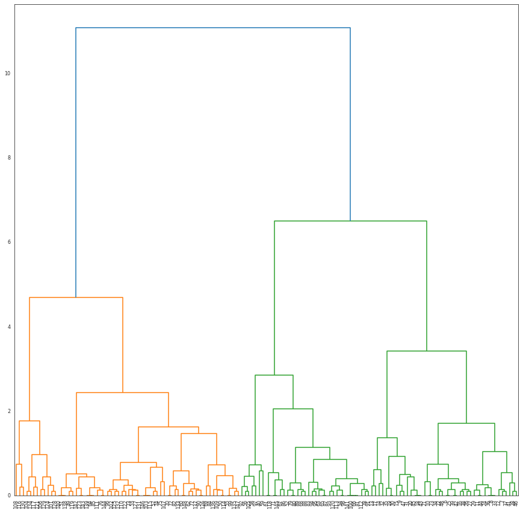

```python
from scipy.cluster.hierarchy import dendrogram, linkage

plt.figure(figsize=(15,15))


Z = linkage(New_data, 'ward')

dendrogram(Z, labels=New_data.index, leaf_rotation=90)


plt.xticks(fontsize = 8)
plt.yticks(fontsize = 8)

# Show the graph
plt.show()

# https://www.python-graph-gallery.com/400-basic-dendrogram
# https://www.python-graph-gallery.com/401-customised-dendrogram
```

### Exploration Interpretation:

In this part, I have plotted all the dataset that above the first 6 rows. To see the initial dendrogram before building up the small practical simple.

```python
# Generate the first 6 rows of the df "Initial dataset"

data = df[["sepal_width","sepal_length"]].head(6)
data
```

|  | sepal_width | sepal_length |
| --- | --- | --- |
| 0 | 3.0 | 4.9 |
| 1 | 3.2 | 4.7 |
| 2 | 3.1 | 4.6 |
| 3 | 3.6 | 5.0 |
| 4 | 3.9 | 5.4 |
| 5 | 3.4 | 4.6 |

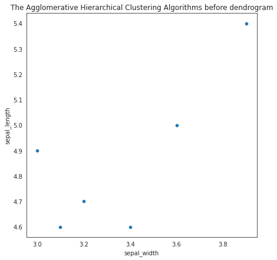

```python
#scatter chart

sns.set_style("white")

plt.figure(figsize=(7,7))

sns.scatterplot(data=data, x="sepal_width", y="sepal_length", palette="mako", legend=False)
plt.title("The Agglomerative Hierarchical Clustering Algorithms before dendrogram")

plt.show()
```

### Exploration Interpretation:

```python
import numpy as np

# initializing points in numpy arrays
# Basically I took the first 6 rows and convert them into arrays.

point1 = np.array((3,3.2,3.1,3.6,3.9,3.4))
point2 = np.array((4.9,4.7,4.6,5,5.4,4.6))

# finding sum of squares

sum_sq = np.sum(np.square(point1 - point2))

# Doing squareroot and
# printing Euclidean distance

print("The value of the Euclidean Distance is:", round(np.sqrt(sum_sq), 2))
```

```
The value of the Euclidean Distance is: 3.71
```

### *Plotting the dendrogram that's related to the 6 rows*

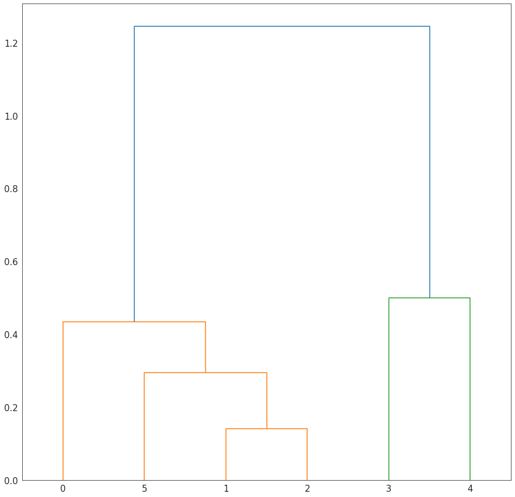

```python
from scipy.cluster.hierarchy import dendrogram, linkage

plt.figure(figsize=(15,15))


Z = linkage(data, 'ward')

dendrogram(Z, labels=data.index, leaf_rotation=90)
#plt.axhline(y=0.14, c='red', lw=1, linestyle='dashed')


plt.xticks(fontsize = 15, rotation='horizontal')
plt.yticks(fontsize = 15, rotation='horizontal')

# Show the graph
plt.show()

# https://www.python-graph-gallery.com/400-basic-dendrogram
# https://www.python-graph-gallery.com/401-customised-dendrogram
```

### Exploration Interpretation:

The opportunity to immplement the algorithms and math in both cases and gives the same results, that's optimal analysis.